# Testing of Hypothesis using R

Tanujit Chakraborty

Statistical Inference (SI 350) Course

In this document, we shall illustrate the usage of performing hypothesis testing using R. This includes the t-tests – one sample Student’s t-test, two-sample t-test, pooled t-test and the paired t-test. Other tests include the large sample tests for proportion(s) and testing of variances.

We first illustrate the procedures with simulated examples.

### One-sample t-test

We start with a random sample $X_1,\ldots,X_n \stackrel{iid}{\sim} N(\mu, \sigma^2)$. The null hypothesis is given by
$$H_0: \mu \leq \mu_0\; vs\; H_1:\mu > \mu_0$$
We first generate some simulated data with true value of $\mu = 2$ and $\sigma = 2$, and sample size $n = 25.$ We take the null value $\mu_0 = 3$.

```r
set.seed(8885)
Xsamp <- rnorm(n = 25, mean = 2, sd = 2)
```

Note: This is a simulated scenario, where we actually are aware of the true value of the parameters. In the real-life scenario, we would have no idea about the true value of the parameters, and our goal would be to test the population mean using the data given. This exercise is to illustrate the t-test procedure, and check whether we are getting desired results or not.

The function that we are going to use is $\texttt{t.test}$. Check the help file for the function using the command $\texttt{?t.test}$.

```r
mytest <- t.test(Xsamp, alternative = "greater", mu = 3)
mytest
```

```
##
##  One Sample t-test
##
## data:  Xsamp
## t = -1.3467, df = 24, p-value = 0.9047
## alternative hypothesis: true mean is greater than 3
## 95 percent confidence interval:
##  1.954146      Inf
## sample estimates:
## mean of x
##   2.53935
```

To specifically extract the p-value of the test, we write

```r
mytest$p.value
```

```
## [1] 0.9046778
```

As we would have expected, the p-value of this test came out to be quite high, since the true value if $\mu$ is, in fact, equal to 2. Our data didn;t provide evidence that the true mean is greater than 3. Of course, if we had changed our null value to something closer to 2, it would be harder to distinguish. Let’s check this.

```r
t.test(Xsamp, alternative = "greater", mu = 2.1)
```

```
##
##  One Sample t-test
##
## data:  Xsamp
## t = 1.2845, df = 24, p-value = 0.1056
## alternative hypothesis: true mean is greater than 2.1
## 95 percent confidence interval:
##  1.954146      Inf
## sample estimates:
## mean of x
##   2.53935
```

Notice the drop in the p-value of the test.

> Can you argue why the p-value has dropped?

Take another case.

```r
t.test(Xsamp, alternative = "greater", mu = 1.9)
```

```
##
##  One Sample t-test
##
## data:  Xsamp
## t = 1.8692, df = 24, p-value = 0.03692
## alternative hypothesis: true mean is greater than 1.9
## 95 percent confidence interval:
##  1.954146      Inf
## sample estimates:
## mean of x
##   2.53935
```

The p-value has dropped below 0.05 now, and if we are using a level $\alpha = 0.05$, we would reject $H_0$ in favour of $H_1$ (and we would have taken the correct decision in this case). We would still fail to reject it at $\alpha = 0.01$. Taking the null value away from the actual true value towards the region supported by $H_0$ would result in lower p-values. Let’s check.

```r
t.test(Xsamp, alternative = "greater", mu = 1)
```

```
##
##  One Sample t-test
##
## data:  Xsamp
## t = 4.5004, df = 24, p-value = 7.398e-05
## alternative hypothesis: true mean is greater than 1
## 95 percent confidence interval:
##  1.954146      Inf
## sample estimates:
## mean of x
##   2.53935
```

We can actually find the p-value as a function of $\mu_0$ and the sample size $n$, keeping the true values of the parameters fixed. In R, we can quickly write a function to do this.

```r
func.p.val <- function(n, mu0){
  set.seed(100)
  Xsamp <- rnorm(n, mean = 2, sd = 2) #generating random sample of size n from N(2,4)
  p.val <- t.test(Xsamp, alternative = "greater", mu = mu0)$p.value #calculate p-value
  return(p.val)
}
```

```r
n <- seq(5,25, by = 5)
mu0 <- seq(-5,5, by = 0.1)

pvals <- matrix(0, nrow = length(n), ncol = length(mu0))

for(i in 1:length(n)){
  for(j in 1:length(mu0)){
    pvals[i,j] <- func.p.val(n[i],mu0[j])
  }
}
```

Now let us plot the p-values for different values of the sample size and null values.

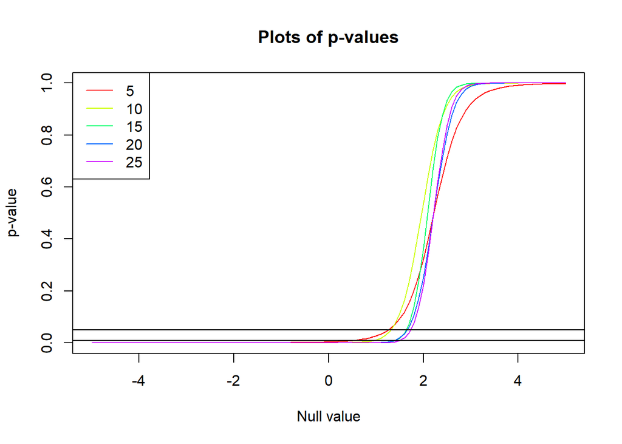

```r
cl <- rainbow(length(n))

plot(mu0, pvals[1, ], type = "l", main = "Plots of p-values", xlab = "Null value",
     ylab = "p-value", ylim = c(min(pvals),1), col = cl[1])

for(i in 2:length(n)){
  lines(mu0, pvals[i, ], type = "l", col = cl[i])
}
abline(h = 0.05)
abline(h = 0.01)
legend("topleft", legend = n, lty = 1, col = cl)
```

Let us zoom it in near the true value of 2.

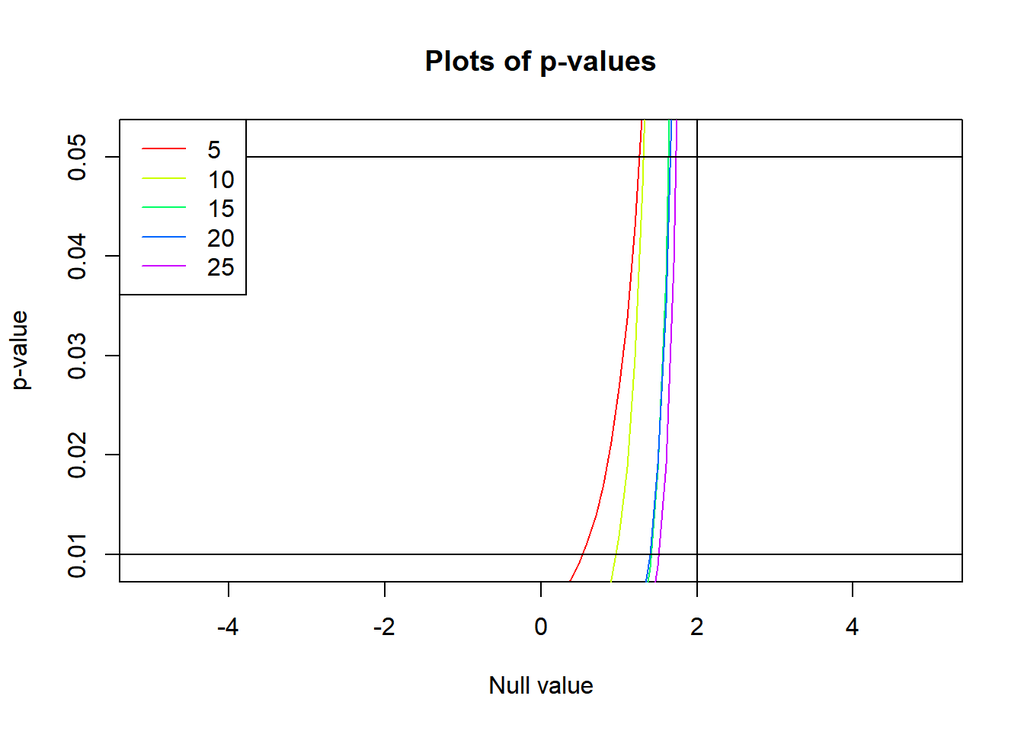

```r
cl <- rainbow(length(n))

plot(mu0, pvals[1, ], type = "l", main = "Plots of p-values", xlab = "Null value",
     ylab = "p-value", ylim = c(0.009,0.052), col = cl[1])

for(i in 2:length(n)){
  lines(mu0, pvals[i, ], type = "l", col = cl[i])
}
abline(h = 0.05)
abline(h = 0.01)
abline(v = 2)
legend("topleft", legend = n, lty = 1, col = cl)
```

You may try with multiple samples by changing the seed above. Results will vary due to uncertainty, but overall, the conclusions would remain the same.

To work with other alternatives, you should change the $\texttt{alternative}$ to $\texttt{"lesser"}$ for left-tailed tests, and to $\texttt{"two-sided"}$ for two-tailed tests.

> Pro tip: Usage of $\texttt{"g","l","t"}$ also works! Check it out!

## Two-sample t-tests

We now move on to examples illustrating two sample t-tests.

### Behrens-Fisher Problem

We start off with the [Behrens-Fisher problem](https://en.wikipedia.org/wiki/Behrens%E2%80%93Fisher_problem), which deals with the comparison of means of two Normal populations when the population variances are not equal. We shall be using the Satthertwaite approximation for this, and the corresponding test is called the Welsh t-test.

We shall illustrate this with a simulation.

Consider
$$X_1,\ldots,X_m \stackrel{iid}{\sim} N(\mu_1,\sigma_1^2),$$
$$Y_1,\ldots,Y_n \stackrel{iid}{\sim} N(\mu_2,\sigma_2^2)$$
$X$ and $Y$ data are independent.

We wish to test the hypothesis
$$H_0: \mu_1 - \mu_2 \leq \mu_0 \; vs.\; H_1: \mu_1 - \mu_2 > \mu_0.$$

Let us first generate some simulated data.

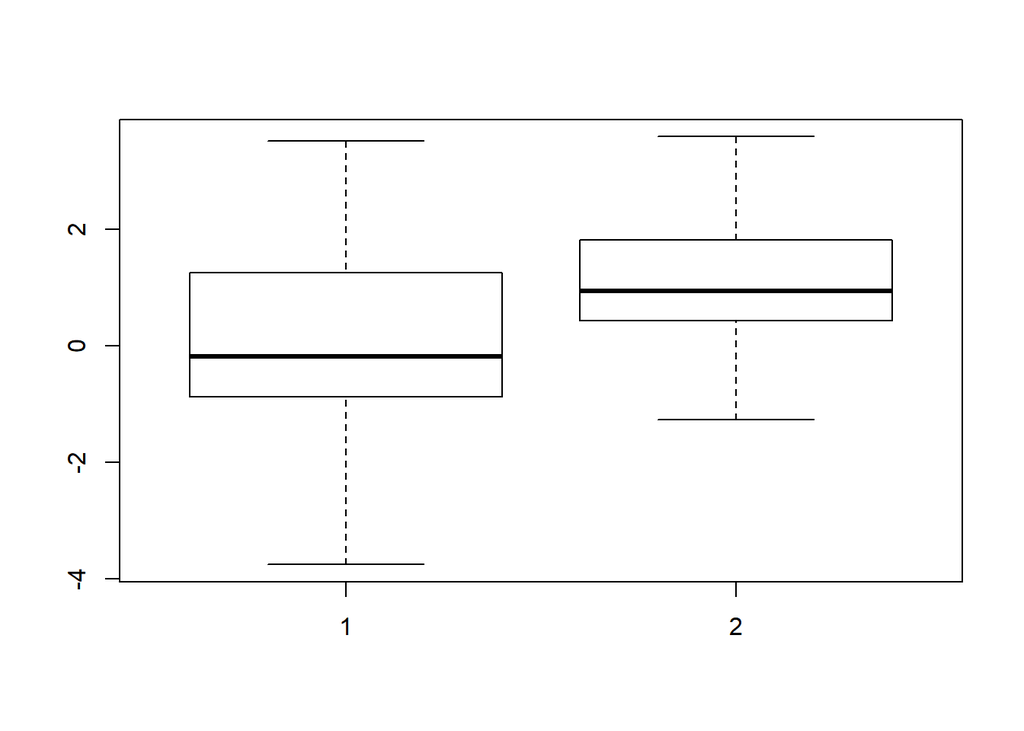

```r
Xsamp <- rnorm(25, mean = 0, sd = 2)
Ysamp <- rnorm(20, mean = 1, sd = 1)

boxplot(Xsamp, Ysamp)
```

Time for t-testing. Take null value of difference to be zero.

```r
mytest2 <- t.test(Xsamp, Ysamp, alternative = "g", mu = 0)
mytest2
```

```
##
##  Welch Two Sample t-test
##
## data:  Xsamp and Ysamp
## t = -2.0846, df = 41.581, p-value = 0.9784
## alternative hypothesis: true difference in means is greater than 0
## 95 percent confidence interval:
##  -1.747405       Inf
## sample estimates:
## mean of x mean of y
## 0.1096918 1.0767013
```

In case you had to test whether $\mu_2$ is greater than $\mu_1$ by 0.5, we can do it in two different ways as follows.

```r
t.test(Xsamp, Ysamp, alternative = "l", mu = -0.5)
```

```
##
##  Welch Two Sample t-test
##
## data:  Xsamp and Ysamp
## t = -1.0068, df = 41.581, p-value = 0.1599
## alternative hypothesis: true difference in means is less than -0.5
## 95 percent confidence interval:
##        -Inf -0.1866143
## sample estimates:
## mean of x mean of y
## 0.1096918 1.0767013
```

```r
t.test(Ysamp, Xsamp, alternative = "g", mu = 0.5)
```

```
##
##  Welch Two Sample t-test
##
## data:  Ysamp and Xsamp
## t = 1.0068, df = 41.581, p-value = 0.1599
## alternative hypothesis: true difference in means is greater than 0.5
## 95 percent confidence interval:
##  0.1866143       Inf
## sample estimates:
## mean of x mean of y
## 1.0767013 0.1096918
```

### Pooled t-test

Now we move on to pooled t-test. As you might recall, we should be using pooled t-testing procedure if the two population variances are equal.

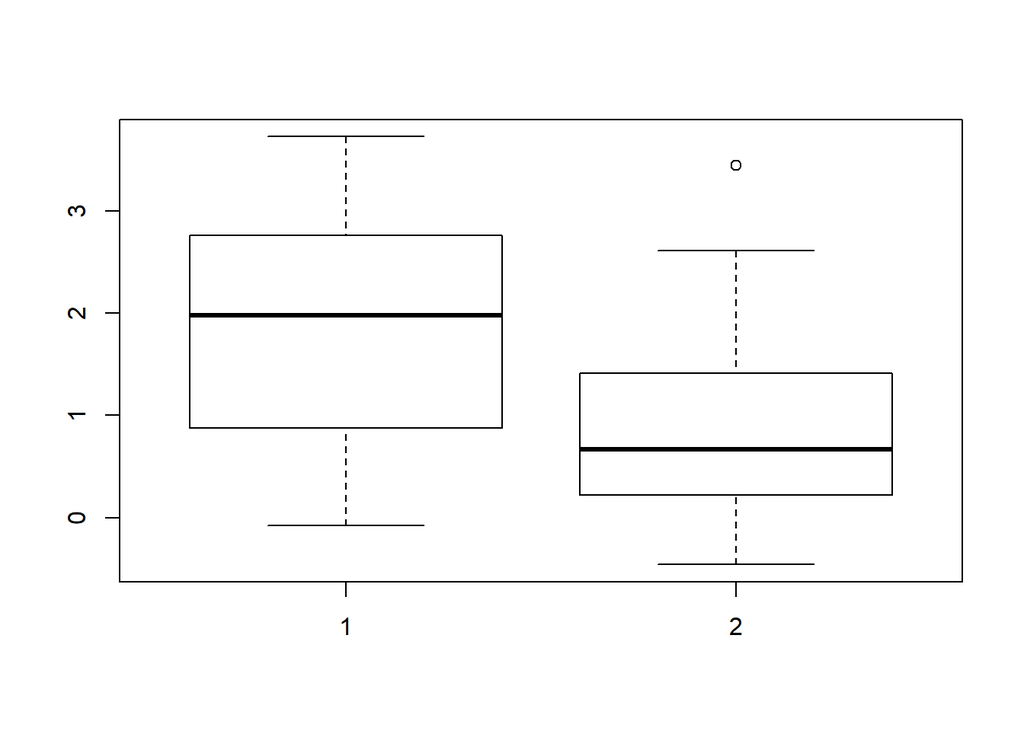

```r
Xsamp <- rnorm(20, mean = 2, sd = 1)
Ysamp <- rnorm(30, mean = 1, sd = 1)
boxplot(Xsamp, Ysamp)
```

You can see that we have used the same variance to generate our samples. Suppose the problem is to check whether the means differ, under the assumption that the variances are unknown but equal.

```r
mytest.pooled <- t.test(Xsamp, Ysamp, alternative = "t", mu = 0, var.equal = TRUE)
mytest.pooled
```

```
##
##  Two Sample t-test
##
## data:  Xsamp and Ysamp
## t = 2.9634, df = 48, p-value = 0.004724
## alternative hypothesis: true difference in means is not equal to 0
## 95 percent confidence interval:
##  0.2928261 1.5287200
## sample estimates:
## mean of x mean of y
## 1.8358720 0.9250989
```

Notice that we have used the additional argument of $\texttt{var.equal = TRUE}$ to incorporate the additional information in our testing procedure.

### Paired t-test

We now move on to the paired t-test procedure, for samples coming in pairs from a Bivariate Normal distribution. We have,
$$(X_1,Y_1),\ldots,(X_n,Y_n) \stackrel{iid}{\sim} N_2(\mu_1,\mu_2,\sigma_1^2,\sigma_2^2,\rho)$$
We wish to test the hypotheses
$$H_0: \mu_1 - \mu_2 = \mu_0 \; vs.\; H_1:\mu_1 - \mu_2 \neq \mu_0.$$

First we generate random samples from a Bivariate Normal distribution.

```r
Xsamp <- rnorm(25, mean = 2, sd = 2)
Ysamp <- 0.5*Xsamp + rnorm(25, mean = 1, sd = 1)
```

Notice that the $Y$ samples are linearly related to $X$ samples, and hence a correlation between them are established. You can plot the data to visualize this.

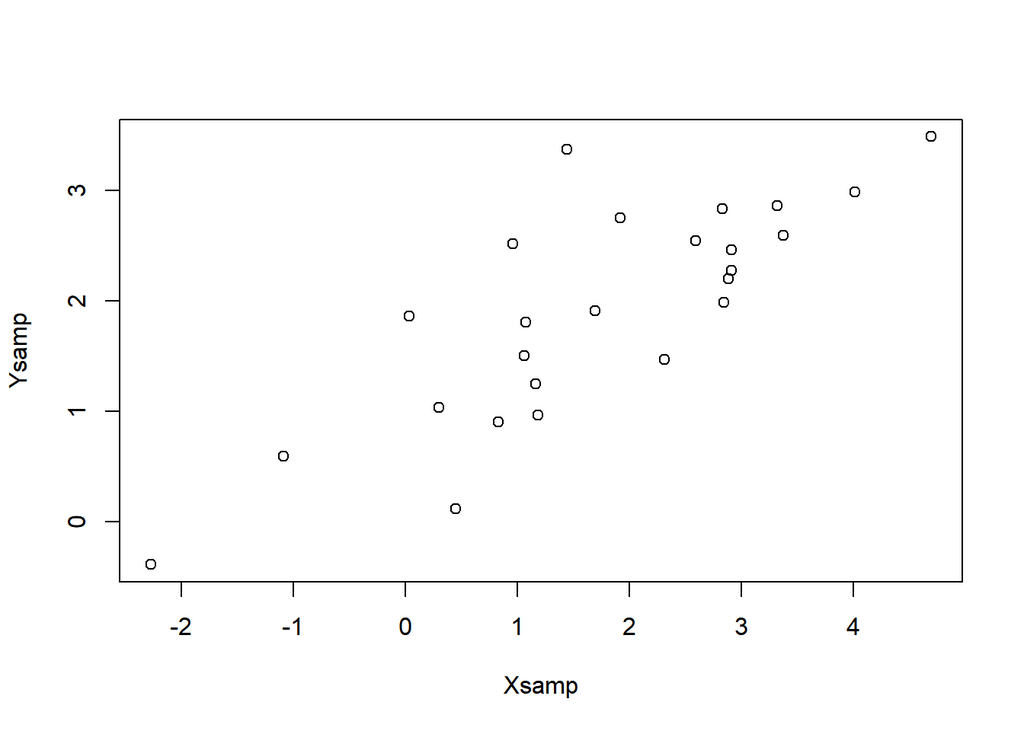

```r
plot(Xsamp, Ysamp)
```

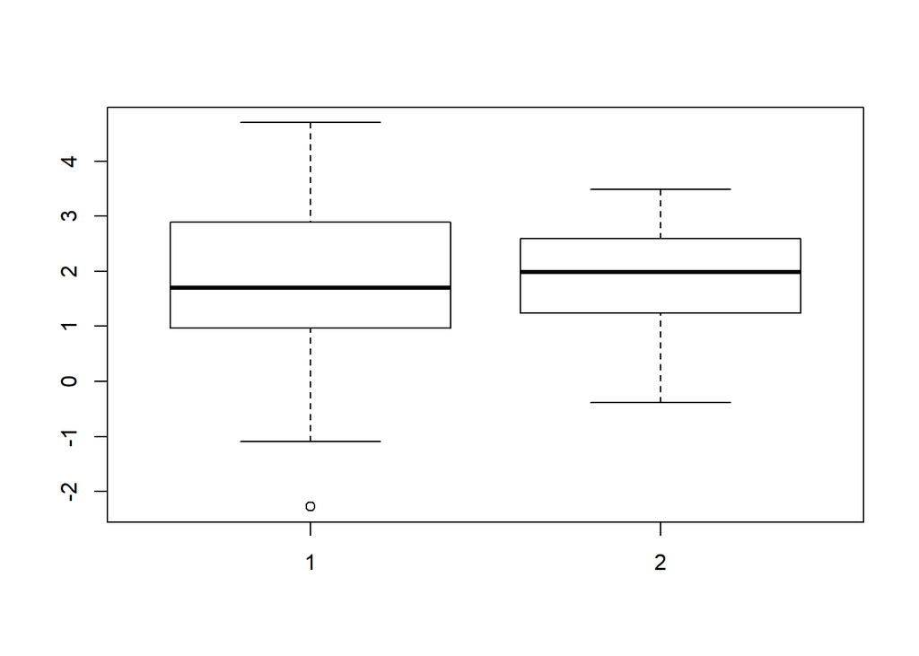

```r
boxplot(Xsamp, Ysamp)
```

The true means are $\mu_1 = 2$ and $\mu_2 = 0.5\times 2 + 1 = 2$, so that the means are, in fact, equal. We shall test this in light of the data.

```r
mytest.paired <- t.test(Xsamp, Ysamp, alternative = "t", mu = 0, paired = TRUE)
mytest.paired
```

```
##
##  Paired t-test
##
## data:  Xsamp and Ysamp
## t = -0.89964, df = 24, p-value = 0.3773
## alternative hypothesis: true difference in means is not equal to 0
## 95 percent confidence interval:
##  -0.5820331  0.2286589
## sample estimates:
## mean of the differences
##              -0.1766871
```

Note the usage of the argument $\texttt{paired = TRUE}$ in the command above.

## Testing of variances

We now illustrate testing of variances of two independent Normal populations. Suppose

$$X_1,\ldots,X_m \stackrel{iid}{\sim} N(\mu_1,\sigma_1^2),$$
$$Y_1,\ldots,Y_n \stackrel{iid}{\sim} N(\mu_2,\sigma_2^2)$$
We wish to test hypotheses concerning their respective variances. Let’s consider testing
$$H_0:\sigma_1^2 \leq \sigma_2^2 \; vs.\; H_1:\sigma_1^2 > \sigma_2^2.$$

We use the command $\texttt{var.test}$ for this.

```r
Xsamp <- rnorm(15, mean = 2, sd = 2)
Ysamp <- rnorm(20, mean = 5, sd = 4)

vartest <- var.test(Xsamp, Ysamp, alternative = "g")
vartest
```

```
##
##  F test to compare two variances
##
## data:  Xsamp and Ysamp
## F = 0.36659, num df = 14, denom df = 19, p-value = 0.9696
## alternative hypothesis: true ratio of variances is greater than 1
## 95 percent confidence interval:
##  0.1625231       Inf
## sample estimates:
## ratio of variances
##          0.3665894
```

## Practice Problems

Let’s practice with some real-life problems.

### Problem 1

*In the near future, nations will likely have to do more to save the environment. Possible actions include reducing energy use and recycling. Currently, most products manufactured from recycled material are considerably more expensive than those manufactured from material found in the earth. For examples, it is approximately three times as expensive to produce glass bottles from recycled glass than from silica sand, soda ash, and limestone, all plentiful materials mined in numerous countries. It is more expensive to manufacture aluminium cans from recycled cans than from bauxite. Newspapers are an exception. It can be profitable to recycle newspaper. A major expense is the collection from homes. In recent years, many companies have gone into the business of collecting used newspapers from households and recycling them. A financial analyst for one such company has recently computed that the firm would make a profit if the mean weekly newspaper collection from each household exceeded 2.0 pounds. In a study to determine the feasibility of a recycling plant, a random sample of households was drawn from a large community, and the weekly weight of newspapers discarded for recycling for each household was recorded and listed next. Do these data provide sufficient evidence to allow the analyst to conclude that a recycling plant would be profitable? The dataset it in the file **newspaper.csv**.Assume that the weights of newspapers are normally distributed.*

**Solution**. Let us denote the mean weekly weight of the newspapers as $\mu$. To conclude whether a recycling plant will be profitable, we have to test
$$H_0: \mu \leq 2\; vs. \; H_1:\mu > 2.$$

The random sample is assumed to follow a Normal distribution. We should be using a one-sample t-test in this case.

```r
# Read the data file
dat <- read.csv("newspaper.csv", header = TRUE)

# Check the variable names and form of the data
str(dat)
```

```
## 'data.frame':    30 obs. of  1 variable:
##  $ Weight: num  4.286 4.246 0.566 1.176 3.227 ...
```

```r
news.test <- t.test(dat$Weight, alternative = "g", mu = 2)
news.test
```

```
##
##  One Sample t-test
##
## data:  dat$Weight
## t = 3.2684, df = 29, p-value = 0.001392
## alternative hypothesis: true mean is greater than 2
## 95 percent confidence interval:
##  2.426864      Inf
## sample estimates:
## mean of x
##  2.889035
```

The p-value of the test is 0.0013922, which is lower than 0.01. Hence we reject the null hypothesis at 1% level of significance and conclude that there is enough evidence to believe that the recycling plant would be profitable.

## Problem 2

*Chlorofluorocarbons (CFCs) are used in conditioners. However, CFCs damage the ozone layer, which protects us from the suns harmful rays. As a result many jurisdictions have banned the production and use of CFCs. The latest jurisdiction to do so is Gotham city, which has banned the use CFCs in car and truck air conditioners. However, it is not known how many vehicles will be affected by the new legislation. A survey of 650 vehicles was undertaken. Each vehicle was identified as either using CFCs (2) or not (1). Can it be concluded that the percentage of vehicles affected by this legislation is different from 25%? The data is in the file **CFCdata.csv**.*

**Solution**. Let $p$ denote the proportion of vehicles getting affected by the new legislation. We have to test
$$H_0: p = 0.25\; vs. H_1: p \neq 0.25.$$
The sample size is large, given by $n = 650$, and $np_0 = 650 \times 0.25 = 162.5 > 10,$ so that we can use a large-sample testing procedure based on Normal distribution.

The test statistic is given by
$$Z = \dfrac{\hat{p} - p_0}{\sqrt{p_0q_0/n}},$$
where $\hat{p}$ is the sample proportion of vehicles using CFCs (vehicles that are affected by the new legislation). We would reject $H_0$ in favour of $H_1$ if $obsvd(|Z|) > z_{\alpha/2}$, where $\alpha$ is the level of significance of the test.

```r
# Read the dataset
dat <- read.csv("CFCdata.csv", header = TRUE)

str(dat)
```

```
## 'data.frame':    650 obs. of  1 variable:
##  $ CFC.Status: int  1 1 1 1 1 1 2 1 1 1 ...
```

```r
table(dat) # Check number of CFC usage status
```

```
## dat
##   1   2
## 451 199
```

```r
n <- length(dat$CFC.Status) #sample size
p.hat <- sum(dat$CFC.Status == 2)/n #proportion of 2s (using CFC)
p.hat
```

```
## [1] 0.3061538
```

```r
p0 <- 0.25 #null value

Z <- abs((p.hat - p0)/sqrt(p0*(1-p0)/n))
Z
```

```
## [1] 3.306249
```

```r
alpha <- seq(0.01,0.10, by = 0.01)
cutoff <- qnorm(alpha/2, lower.tail = FALSE)

data.frame(alpha = alpha, Reject = Z > cutoff)
```

```
##    alpha Reject
## 1   0.01   TRUE
## 2   0.02   TRUE
## 3   0.03   TRUE
## 4   0.04   TRUE
## 5   0.05   TRUE
## 6   0.06   TRUE
## 7   0.07   TRUE
## 8   0.08   TRUE
## 9   0.09   TRUE
## 10  0.10   TRUE
```

Let us find the p-value of this test. For a one-sample two-sided Z-test, the p-value is given by $2(1 - \phi(|z|))$, which is calculated as

```r
p.val <- 2*(1 - pnorm(Z)) # we have already taken the absolute value while computing Z
p.val
```

```
## [1] 0.0009455404
```

> Using prop.test function

```r
prop.test(x = sum(dat$CFC.Status == 2), n = n, p = 0.25, alternative = "t", correct = F)
```

```
##
##  1-sample proportions test without continuity correction
##
## data:  sum(dat$CFC.Status == 2) out of n, null probability 0.25
## X-squared = 10.931, df = 1, p-value = 0.0009455
## alternative hypothesis: true p is not equal to 0.25
## 95 percent confidence interval:
##  0.2719468 0.3426386
## sample estimates:
##         p
## 0.3061538
```

## Problem 3

*Credit scorecards were designed to be used to help financial institutions make decisions about loan applications. However, some insurance companies have suggested that credit scores could also be used to determine insurance premiums, particularly car insurance. A certain Public Interest Research Group, however, has come out against this proposal. To acquire more information, an executive for a car-insurance company gathered data about a random sample of the companys customers. She recorded whether the individual was involved in the accident in the last 3 years and determined the credit score. Can the executive infer that there is a difference in scores between those who did and those who did not have accidents in a 3 year periods? The related dataset is **Creditscore.csv**. Assume normality of the respective score distribution.*

**Solution**. Let $\mu_1$ and $\mu_2$ respectively denote the mean credit score of individuals involved in an accident and not in a 3 year period. We have to test
$$H_0: \mu_1 - \mu_2 = 0 \; vs. \; \mu_1 - \mu_2 \neq 0.$$

We should be using a two-sample t-test for this problem. Let us first check whether the variances of the two populations can be taken to be equal.

```r
#Read the data file
dat <- read.csv("Creditscore.csv", header = T)
str(dat)
```

```
## 'data.frame':    59 obs. of  2 variables:
##  $ Accident: Factor w/ 2 levels "No","Yes": 2 2 2 2 2 2 2 2 2 2 ...
##  $ Score   : num  588 587 573 566 583 ...
```

```r
Xdat <- dat$Score[dat$Accident == "Yes"]
Ydat <- dat$Score[dat$Accident == "No"]
# Testing equality of variances
var.test(Xdat, Ydat, alternative = "t")
```

```
##
##  F test to compare two variances
##
## data:  Xdat and Ydat
## F = 0.3264, num df = 26, denom df = 31, p-value = 0.004716
## alternative hypothesis: true ratio of variances is not equal to 1
## 95 percent confidence interval:
##  0.1557660 0.7012544
## sample estimates:
## ratio of variances
##          0.3263966
```

The p-value of the F-test is lower than 0.01, and hence we reject the null hypothesis of equality of variances. Hence we should go for the Welsch t-test, and not the pooled one.

```r
t.test(Xdat, Ydat, alternative = "t", var.equal = FALSE)
```

```
##
##  Welch Two Sample t-test
##
## data:  Xdat and Ydat
## t = -6.2285, df = 50.596, p-value = 9.245e-08
## alternative hypothesis: true difference in means is not equal to 0
## 95 percent confidence interval:
##  -23.60836 -12.09731
## sample estimates:
## mean of x mean of y
##  581.1077  598.9605
```

The p-value of the above test is extremely small, and hence we reject the null hypothesis at 1% level of significance and conclude that the credit scores vary.

### Problem 4

*The General Products Company produces and sells a variety of household products. Because of stiff competitions, one of its products, a bath soap, is not selling well. Hoping to improve sales, General Products decided to introduce more attractive packaging. The company’s advertising agency developed two new designs. The First design features several bright colors to distinguish it from other brands. The second design is light green in color with just the company’s logo on it. As a test to determine which design is better, the marketing manager selected two supermarkets. In one supermarket, the soap was packaged in a box using the first design; in the second supermarket, the second design was used. The product scanner at each supermarket tracked every buyer of soap over a 1-week period. The supermarkets recorded the last four digits of the scanner code for each of the five brands of soap the supermarket sold. The code for the General Products brand of soap is 9077 (the other codes are 4255, 3745, 7118, and 8855). After the trial period, the scanner data were transferred to a computer file. Because the first design is more expensive, management has decided to use this design only if there is sufficient evidence to allow it to conclude that design is better. Should management switch to the brightly colored design or the simple green one?*

*Suppose that in the above problem, the additional cost of the brightly colored design requires that it outsell the simple design by more than 3%. Should management switch to the brightly coloured design? The dataset is in **Soap.csv**.*

**Solution**. Let $p_1$ and $p_2$ respectively denote the sales proportion of the General Products’ soap in the first (selling bright designed soap) and second (selling ordinary packaging) supermarkets. We have to test
$$H_0:p_1 \leq p_2 \; vs. H_1: p_1 > p_2.$$
> We shall be using prop.test directly. You can also try finding the value of the test statistic directly and find the p-value.

```r
#Read the data
dat <- read.csv("Soap.csv", header = T)
str(dat)
```

```
## 'data.frame':    1038 obs. of  2 variables:
##  $ Supermarket.1: int  4255 4255 4255 8855 7118 9077 3745 9077 4255 3745 ...
##  $ Supermarket.2: int  4255 9077 8855 9077 8855 4255 9077 7118 8855 3745 ...
```

```r
# Check number of transactions in the supermarkets
n1 <- length(dat$Supermarket.1)
n2 <- length(dat$Supermarket.2)

# Check number of General Products' soap sold
Sales1 <- sum(na.omit(dat$Supermarket.1) == 9077)
Sales2 <- sum(na.omit(dat$Supermarket.2) == 9077)

prop.test(x = c(Sales1,Sales2), n = c(n1,n2), alternative = "g", correct = FALSE)
```

```
##
##  2-sample test for equality of proportions without continuity
##  correction
##
## data:  c(Sales1, Sales2) out of c(n1, n2)
## X-squared = 2.2247, df = 1, p-value = 0.06791
## alternative hypothesis: greater
## 95 percent confidence interval:
##  -0.002461595  1.000000000
## sample estimates:
##    prop 1    prop 2
## 0.1734104 0.1493256
```

> **prop.test** cannot handle non-zero null value of the difference, $p_0$. In those cases, we have to do the test directly.

The second part of the problem mentions that General Products would go for the brightly coloured design of the proportion of sales exceeds the ordinary one by more than 3%. Thus, we are going to test
$$H_0: p_1 - p_2 \leq 0.03\; vs. \; H_1: p_1 - p_2 > 0.03.$$

The test statistic is given by
$$\dfrac{\hat{p}_1 - \hat{p}_2 - 0.03}{\sqrt{\hat{p}_1\hat{q}_1/m + \hat{p}_2\hat{q}_2/n}}.$$

Let’s do this in R.

```r
p1.hat <- Sales1/n1
p2.hat <- Sales2/n2

Z <- (p1.hat - p2.hat - 0.03)/sqrt(p1.hat*(1-p1.hat)/n1 + p2.hat*(1-p2.hat)/n2)
Z
```

```
## [1] -0.3665161
```

```r
alpha <- seq(0.01,0.10, by = 0.01)
cutoff <- qnorm(alpha, lower.tail = FALSE)

data.frame(alpha = alpha, Reject = Z > cutoff)
```

```
##    alpha Reject
## 1   0.01  FALSE
## 2   0.02  FALSE
## 3   0.03  FALSE
## 4   0.04  FALSE
## 5   0.05  FALSE
## 6   0.06  FALSE
## 7   0.07  FALSE
## 8   0.08  FALSE
## 9   0.09  FALSE
## 10  0.10  FALSE
```